# Mudança no consumo de bebidas alcoólicas durante a pandemia de COVID-19

Fatores associados em um estudo com questionário online

Paolla Pinheiro Pacheco (paollapp@id.uff.br)

UFF · Estatística · Prática Estatística 2

20/10/2026

# 1-Introdução

## Contexto: a pandemia de COVID-19

- Declarada em **março de 2020**, alterou a rotina de toda a população
- **Social:** isolamento, escolas e serviços fechados, rotina doméstica reorganizada
- **Econômico:** perda de renda, desemprego e insegurança financeira
- **Comportamental:** estresse, ansiedade, mudança de sono e de hábitos

Essas mudanças afetaram **o que, quanto e como** as pessoas se alimentam.

## Hábitos alimentares e bebidas alcoólicas

**Variável resposta (foco do estudo):** mudança no consumo de bebidas alcoólicas durante a pandemia

- O consumo de álcool pode **aumentar** (estresse, tédio) ou **diminuir** (menos eventos sociais, menos renda)
- Perfil socioeconômico e saúde emocional podem influenciar esse comportamento

## Problema de pesquisa e objetivos

**Problema:** quais características estão associadas à mudança no consumo de bebidas alcoólicas durante a pandemia?

**Objetivo geral:** avaliar a associação entre a mudança no consumo de bebidas alcoólicas e as demais variáveis do banco.

- Testar a associação com variáveis **qualitativas** (sociodemográficas, de saúde e hábitos)
- Comparar variáveis **quantitativas** (idade, altura, peso e IMC) entre as categorias da resposta

# 2-Metodologia

## Dados

- **Origem:** questionário online aplicado em **2022**
- **Coleta:* alunas da pós-graduação em Nutrição na UFF
- **Amostra:** **2155** participantes
- **Variável resposta:** mudança no consumo de bebidas alcoólicas, com 4 categorias: *Aumentou*, *Diminuiu*, *Não alterou* e *Não consumo*
- **Nível de significância:** **5%**

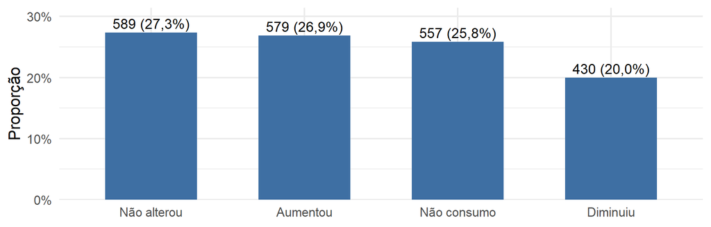

## Variáveis explicativas

**Qualitativas (15)**

- Sociodemográficas: gênero, raça/cor, região, trabalho, renda familiar, escolaridade
- Contexto: isolamento social, COVID-19, dificuldade financeira
- Saúde e hábitos: consulta com nutricionista, tabagismo, ansiedade, depressão, insônia, enxaqueca

**Quantitativas (4)**

- Idade (anos)
- Altura (m)
- Peso (kg)
- IMC (kg/m²)

Categorias pequenas de Raça/Cor, Escolaridade e Gênero foram **agrupadas** para garantir contagens adequadas.

## Métodos: variáveis qualitativas

| Método | Para que serve | Condição |
| --- | --- | --- |
| **Qui-quadrado de Pearson** | testar independência | esperados ≥ 5 nas caselas |
| **Teste exato de Fisher** | alternativa ao qui-quadrado | usado em *gênero* e *escolaridade* (esperados < 5) |
| **V de Cramér** | intensidade da associação | tabelas de contingência |
| **Resíduos padronizados** | identificar caselas influentes | analisados só se p < 0,05; \|z\| > 1,96 |

## Métodos: variáveis quantitativas

| Método | Para que serve | Condição |
| --- | --- | --- |
| **Shapiro-Wilk** e gráficos | avaliar normalidade por grupo | inspeção visual + teste |
| **Levene** | homogeneidade de variâncias | define qual ANOVA usar |
| **ANOVA clássica** | comparar médias | variâncias homogêneas |
| **ANOVA de Welch** | comparar médias | variâncias heterogêneas |
| **Tukey / Games-Howell** | comparações múltiplas | após ANOVA significativa |

**Pacotes do R:** tidyverse, readxl, gtsummary, gt, rstatix, DescTools · **Quarto** para os slides

# 3-Resultados

## Variáveis qualitativas (1/3): perfil sociodemográfico

| **Variáveis** | **Mudança no consumo de bebidas alcoólicas** **Aumentou** 579 (27%) | **Mudança no consumo de bebidas alcoólicas** **Diminuiu** 430 (20%) | **Mudança no consumo de bebidas alcoólicas** **Não alterou** 589 (27%) | **Mudança no consumo de bebidas alcoólicas** **Não consumo** 557 (26%) | **p-value** | **Cramér** |  |  |
| --- | --- | --- | --- | --- | --- | --- | --- | --- |
| Gênero<sup>F</sup> |  |  |  |  |  |  | 0.178 | 0.043 |
| Feminino | 434 (27%) | 307 (19%) | 433 (27%) | 428 (27%) |  |  |  |  |
| Masculino | 142 (26%) | 119 (22%) | 152 (28%) | 129 (24%) |  |  |  |  |
| Outro/Não Informado | 3 (27%) | 4 (36%) | 4 (36%) | 0 (0%) |  |  |  |  |
| Raça/cor<sup>Q</sup> |  |  |  |  | 0.072 | 0.049 |  |  |
| Branca | 380 (28%) | 269 (20%) | 384 (29%) | 313 (23%) |  |  |  |  |
| Parda | 143 (25%) | 116 (20%) | 146 (25%) | 171 (30%) |  |  |  |  |
| Preta | 41 (25%) | 35 (21%) | 41 (25%) | 49 (30%) |  |  |  |  |
| Outras/Não Informado | 15 (22%) | 10 (15%) | 18 (27%) | 24 (36%) |  |  |  |  |
| Região de residência<sup>Q</sup> |  |  |  |  | 0.034 | 0.059 |  |  |
| Centro-oeste | 48 (22%) | 41 (19%) | 65 (30%) | 63 (29%) |  |  |  |  |
| Nordeste | 74 (28%) | 42 (16%) | 74 (28%) | 78 (29%) |  |  |  |  |
| Norte | 79 (26%) | 47 (15%) ▼ | 82 (27%) | 97 (32%) ▲ |  |  |  |  |
| Sudeste | 251 (28%) | 207 (23%) ▲ | 243 (27%) | 206 (23%) ▼ |  |  |  |  |
| Sul | 127 (28%) | 93 (20%) | 125 (27%) | 113 (25%) |  |  |  |  |

F: Fisher; Q: qui-quadrado. Linhas somam 100%. ▲ acima do esperado (resíduo > 1,96); ▼ abaixo do esperado (resíduo < -1,96). Resíduos analisados apenas quando p < 0,05.

## Variáveis qualitativas (2/3): trabalho, renda e escolaridade

| **Variáveis** | **Mudança no consumo de bebidas alcoólicas** **Aumentou** 579 (27%) | **Mudança no consumo de bebidas alcoólicas** **Diminuiu** 430 (20%) | **Mudança no consumo de bebidas alcoólicas** **Não alterou** 589 (27%) | **Mudança no consumo de bebidas alcoólicas** **Não consumo** 557 (26%) | **p-value** | **Cramér** |  |  |
| --- | --- | --- | --- | --- | --- | --- | --- | --- |
| Situação de trabalho<sup>Q</sup> |  |  |  |  |  |  | <0.001 | 0.150 |
| Sim | 461 (29%) ▲ | 275 (17%) ▼ | 466 (29%) ▲ | 381 (24%) ▼ |  |  |  |  |
| Não | 118 (21%) ▼ | 155 (27%) ▲ | 123 (22%) ▼ | 176 (31%) ▲ |  |  |  |  |
| Faixa de renda familiar<sup>Q</sup> |  |  |  |  | <0.001 | 0.103 |  |  |
| até R$ 1254,00 | 48 (20%) ▼ | 58 (24%) | 53 (22%) ▼ | 86 (35%) ▲ |  |  |  |  |
| entre R$ 1.255 - R$ 8.640 | 307 (25%) ▼ | 268 (22%) ▲ | 330 (27%) | 325 (26%) |  |  |  |  |
| mais de R$ 8.640 | 224 (33%) ▲ | 104 (15%) ▼ | 206 (30%) ▲ | 146 (21%) ▼ |  |  |  |  |
| Nível de escolaridade<sup>F</sup> |  |  |  |  | <0.001 | 0.081 |  |  |
| Fundamental ou menos/NI | 7 (30%) | 5 (22%) | 6 (26%) | 5 (22%) |  |  |  |  |
| Ensino Médio Completo | 169 (23%) ▼ | 187 (25%) ▲ | 183 (25%) ▼ | 203 (27%) |  |  |  |  |
| Ensino Superior Completo | 106 (25%) | 92 (22%) | 102 (25%) | 116 (28%) |  |  |  |  |
| Pós-graduação | 297 (30%) ▲ | 146 (15%) ▼ | 298 (31%) ▲ | 233 (24%) |  |  |  |  |
| Dificuldade financeira<sup>Q</sup> |  |  |  |  | <0.001 | 0.122 |  |  |
| Sim | 90 (23%) ▼ | 109 (28%) ▲ | 76 (19%) ▼ | 119 (30%) ▲ |  |  |  |  |
| Não | 489 (28%) ▲ | 321 (18%) ▼ | 513 (29%) ▲ | 438 (25%) ▼ |  |  |  |  |

F: Fisher; Q: qui-quadrado. Linhas somam 100%. ▲ acima do esperado (resíduo > 1,96); ▼ abaixo do esperado (resíduo < -1,96). Resíduos analisados apenas quando p < 0,05.

## Variáveis qualitativas (3/3): contexto, saúde e hábitos

| **Variáveis** | **Mudança no consumo de bebidas alcoólicas** **Aumentou** 579 (27%) | **Mudança no consumo de bebidas alcoólicas** **Diminuiu** 430 (20%) | **Mudança no consumo de bebidas alcoólicas** **Não alterou** 589 (27%) | **Mudança no consumo de bebidas alcoólicas** **Não consumo** 557 (26%) | **p-value** | **Cramér** |  |  |
| --- | --- | --- | --- | --- | --- | --- | --- | --- |
| Isolamento social<sup>Q</sup> |  |  |  |  |  |  | 0.009 | 0.073 |
| Sim | 311 (26%) | 241 (20%) | 308 (26%) ▼ | 343 (29%) ▲ |  |  |  |  |
| Não | 268 (28%) | 189 (20%) | 281 (30%) ▲ | 214 (22%) ▼ |  |  |  |  |
| Diagnóstico de COVID-19<sup>Q</sup> |  |  |  |  | 0.028 | 0.065 |  |  |
| Sim | 174 (30%) | 125 (21%) | 158 (27%) | 126 (22%) ▼ |  |  |  |  |
| Não | 405 (26%) | 305 (19%) | 431 (27%) | 431 (27%) ▲ |  |  |  |  |
| Consulta com nutricionista<sup>Q</sup> |  |  |  |  | 0.392 | 0.037 |  |  |
| Sim | 118 (29%) | 83 (20%) | 98 (24%) | 109 (27%) |  |  |  |  |
| Não | 461 (26%) | 347 (20%) | 491 (28%) | 448 (26%) |  |  |  |  |
| Hábito de fumar cigarro<sup>Q</sup> |  |  |  |  | 0.002 | 0.083 |  |  |
| Sim | 42 (40%) ▲ | 22 (21%) | 28 (27%) | 13 (12%) ▼ |  |  |  |  |
| Não | 537 (26%) ▼ | 408 (20%) | 561 (27%) | 544 (27%) ▲ |  |  |  |  |
| Ansiedade na pandemia<sup>Q</sup> |  |  |  |  | <0.001 | 0.106 |  |  |
| Sim | 301 (29%) | 232 (22%) ▲ | 237 (23%) ▼ | 276 (26%) |  |  |  |  |
| Não | 278 (25%) | 198 (18%) ▼ | 352 (32%) ▲ | 281 (25%) |  |  |  |  |
| Depressão na pandemia<sup>Q</sup> |  |  |  |  | 0.011 | 0.072 |  |  |
| Sim | 104 (30%) | 77 (22%) | 70 (20%) ▼ | 98 (28%) |  |  |  |  |
| Não | 475 (26%) | 353 (20%) | 519 (29%) ▲ | 459 (25%) |  |  |  |  |
| Insônia na pandemia<sup>Q</sup> |  |  |  |  | 0.543 | 0.032 |  |  |
| Sim | 80 (27%) | 60 (21%) | 70 (24%) | 82 (28%) |  |  |  |  |
| Não | 499 (27%) | 370 (20%) | 519 (28%) | 475 (25%) |  |  |  |  |
| Enxaqueca na pandemia<sup>Q</sup> |  |  |  |  | 0.572 | 0.030 |  |  |
| Sim | 81 (26%) | 70 (22%) | 79 (25%) | 85 (27%) |  |  |  |  |
| Não | 498 (27%) | 360 (20%) | 510 (28%) | 472 (26%) |  |  |  |  |

F: Fisher; Q: qui-quadrado. Linhas somam 100%. ▲ acima do esperado (resíduo > 1,96); ▼ abaixo do esperado (resíduo < -1,96). Resíduos analisados apenas quando p < 0,05.

## Interpretação: variáveis qualitativas

- **Sem associação:** gênero, raça/cor, consulta com nutricionista, insônia e enxaqueca
- **Associação com maior intensidade (V de Cramér):** situação de trabalho, dificuldade financeira, ansiedade e renda, todas de **intensidade fraca**
- **Trabalho, renda e escolaridade:** maior renda e pós-graduação com mais *Aumentou* e *Não alterou*; menor renda com mais *Não consumo*
- **Dificuldade financeira:** mais *Diminuiu* e *Não consumo* e menos *Não alterou*
- **Saúde e hábitos:** ansiedade com mais *Diminuiu*; tabagismo com mais *Aumentou*

## Variáveis quantitativas

| **Variáveis** | **Consumo de Bebidas Alcoólicas** **Aumentou** 579 (27%) | **Consumo de Bebidas Alcoólicas** **Diminuiu** 430 (20%) | **Consumo de Bebidas Alcoólicas** **Não alterou** 589 (27%) | **Consumo de Bebidas Alcoólicas** **Não consumo** 557 (26%) | **Levene** | **Teste** | **p-value** | **Comparações Múltiplas** |  |  |  |  |
| --- | --- | --- | --- | --- | --- | --- | --- | --- | --- | --- | --- | --- |
| Idade (anos) | 34 (11) | 33 (13) | 36 (13) | 35 (13) |  |  |  |  | 0,009 | ANOVA de Welch | <0.001 | Não alterou > Diminuiu (p < 0,001) Não alterou > Aumentou (p = 0,005) |
| Altura (m) | 1.65 (0.08) | 1.66 (0.09) | 1.66 (0.08) | 1.65 (0.09) | 0,354 | ANOVA clássica | 0.011 | Diminuiu > Não consumo (p = 0,015) |  |  |  |  |
| Peso (kg) | 70 (16) | 71 (16) | 70 (15) | 70 (17) | 0,305 | ANOVA clássica | 0.646 | Sem diferenças significativas |  |  |  |  |
| IMC (kg/m²) | 25.6 (4.7) | 25.6 (5.2) | 25.4 (5.0) | 25.7 (5.5) | 0,044 | ANOVA de Welch | 0.810 | Sem diferenças significativas |  |  |  |  |

Média (desvio padrão). Levene: p-valor da homogeneidade de variâncias. Tukey (ANOVA clássica) ou Games-Howell (Welch). “A > B”: média de A maior que a de B.

## Pressupostos das variáveis quantitativas

| Variável | Shapiro: Aumentou | Shapiro: Diminuiu | Shapiro: Não alterou | Shapiro: Não consumo | Levene (p) | Variâncias |
| --- | --- | --- | --- | --- | --- | --- |
| Idade | <0,001 | <0,001 | <0,001 | <0,001 | 0,009 | Heterogêneas |
| Altura | <0,001 | 0,001 | <0,001 | <0,001 | 0,354 | Homogêneas |
| Peso | <0,001 | <0,001 | <0,001 | <0,001 | 0,305 | Homogêneas |
| IMC | <0,001 | <0,001 | <0,001 | <0,001 | 0,044 | Heterogêneas |

Com amostra grande, o Shapiro-Wilk rejeita a normalidade com facilidade; a ANOVA é considerada **robusta** nesse cenário, e a homogeneidade (Levene) define o teste.

## Interpretação: variáveis quantitativas

- **Idade:** diferença entre as categorias; quem **não alterou** o consumo tende a ser mais velho
- **Altura:** diferença estatística pequena, de cerca de 1 cm, de pouca relevância prática
- **Peso e IMC:** **sem diferença** entre as categorias

# 4-Síntese

## Principais achados

**Qualitativas, com associação (p < 0,05)**

- Região, trabalho, renda familiar, escolaridade
- Dificuldade financeira, isolamento, COVID-19
- Tabagismo, ansiedade, depressão

**Quantitativas**

- Associação com **idade** e **altura** (esta com pouca relevância prática)
- Sem associação com **peso** e **IMC**

As associações são, em geral, de **intensidade fraca** (V de Cramér abaixo de 0,20).

# 5-Conclusão

## Conclusão

- **Objetivo:** avaliar a associação entre a mudança no consumo de bebidas alcoólicas e as demais variáveis
- Condições **socioeconômicas** (trabalho, renda, escolaridade, dificuldade financeira) e **emocionais** (ansiedade, depressão) estiveram associadas à mudança
- Possível leitura: renda e trabalho influenciam o **acesso** ao álcool; sofrimento emocional pode alterar o consumo
- **Limitações:** estudo transversal, dados autorrelatados, questionário online (possível viés de seleção); as associações **não indicam causalidade**